# Assignment 3

## Exercise 11

```r
stereotypes <- read.csv("~/Downloads/stereotypes.csv", header=T)
```

*Use the `summary()` and `head()` functions to examine the stereotypes object.*

```r
head(stereotypes)
```

|  | population | gender | coffee | computer | shower | beer | tacos | age |
| --- | --- | --- | --- | --- | --- | --- | --- | --- |
| 1 | hippie | female | 1 | 1 | 8 | 0 | 8 | 17 |
| 2 | nerd | female | 2 | 13 | 7 | 0 | 4 | 17 |
| 3 | nerd | female | 6 | 40 | 8 | 0 | 5 | 17 |
| 4 | nerd | female | 3 | 41 | 10 | 0 | 6 | 17 |
| 5 | nerd | female | 15 | 42 | 9 | 0 | 11 | 17 |
| 6 | nerd | female | 6 | 42 | 9 | 0 | 6 | 17 |

```r
summary(stereotypes)
```

```
     population     gender        coffee         computer         shower            beer           tacos
 hippie   :200   female:400   Min.   : 0.00   Min.   : 0.00   Min.   : 0.000   Min.   : 0.00   Min.   : 0.00
 hipster  :199   male  :399   1st Qu.: 6.00   1st Qu.:12.00   1st Qu.: 4.000   1st Qu.: 6.00   1st Qu.:11.00
 metalhead:200                Median :12.00   Median :24.00   Median : 7.000   Median :17.00   Median :14.00
 nerd     :200                Mean   :13.84   Mean   :28.65   Mean   : 6.607   Mean   :21.13   Mean   :14.03
                              3rd Qu.:22.00   3rd Qu.:43.00   3rd Qu.: 9.000   3rd Qu.:33.00   3rd Qu.:17.00
                              Max.   :36.00   Max.   :95.00   Max.   :18.000   Max.   :80.00   Max.   :42.00
      age
 Min.   :17.00
 1st Qu.:20.00
 Median :22.00
 Mean   :22.34
 3rd Qu.:24.00
 Max.   :27.00
```

*Record the answers to the “activity break sections” from Ciera’s visualiztio tutorial here:*  
**Activity Break: There are many ways to subset data**  
*1. Subset the data to only nerds and metalheads*

```r
nerds_and_metalheads <- subset(stereotypes, population == "nerd" | population == "metalhead")
```

*2. Are there more males who binge drink (over 25 a week) and eat over 20 tacos a week in the metal heads of hipster population?*

```r
metal_m_binge <- subset(stereotypes, population == "metalhead" & gender == "male" & beer > 25 & tacos > 20)
nrow(metal_m_binge)
```

```
[1] 68
```

```r
hipster_m_binge <- subset(stereotypes, population == "hipster" & gender == "male" & beer > 25 & tacos > 20)
nrow(hipster_m_binge)
```

```
[1] 4
```

```r
#Hypothesis: there are more male metalhead binge drinkers than hipsters
nrow(metal_m_binge) > nrow(hipster_m_binge)
```

```
[1] TRUE
```

There are 68 male metalhead that binge drink 25+ beers and eat 20+ tacos while there are only 4 male hipster that do so.

*3. Do male hippies shower more than female nerds?*

```r
hippie_m_shower <- subset(stereotypes, population == "hippie" & gender == "male" & shower == 0)
nrow(hippie_m_shower)
```

```
[1] 7
```

```r
nerd_f_shower <- subset(stereotypes, population == "nerd" & gender == "female" & shower == 0)
nrow(nerd_f_shower)
```

```
[1] 0
```

```r
#Hypothesis: there are more male hippies that don't shower at all than female nerds
nrow(hippie_m_shower) > nrow(nerd_f_shower)
```

```
[1] TRUE
```

There are 7 male hippies that do not shower at all, while all female nerds do shower.

*4. “==” is a equality operator. This expression will evaluate to true if the left thing being compared to the right is identical.*

**Activity Break: There are many different geoms in ggplot2**

```r
#incorporate ggplot2 library
library(ggplot2)
```

*1. View the distribution of showers. Color by population.*

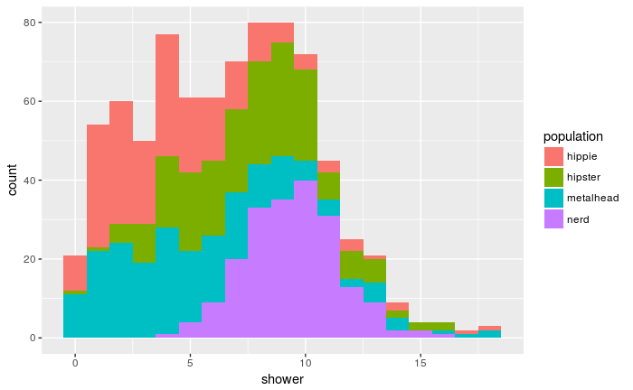

```r
ggplot(data = stereotypes,aes(shower, fill = population)) + geom_histogram(binwidth = 1)
```

*2. View the distribution of beer consumption and color by gender.*

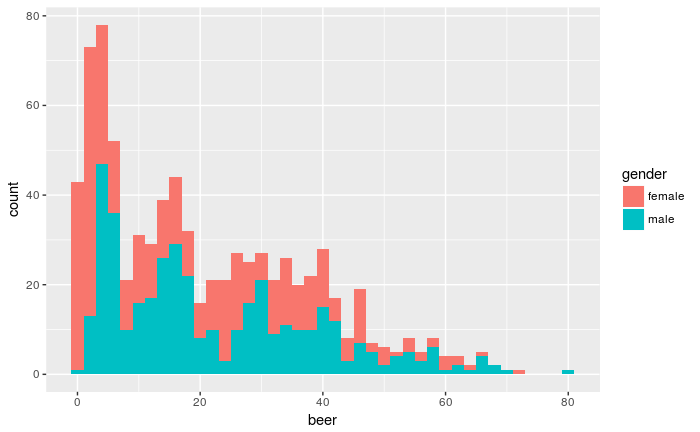

```r
ggplot(data = stereotypes, aes(beer,fill = gender)) + geom_histogram(binwidth = 2)
```

*3. Find a way to create a plot using the geom violin with the stereotype data set.*

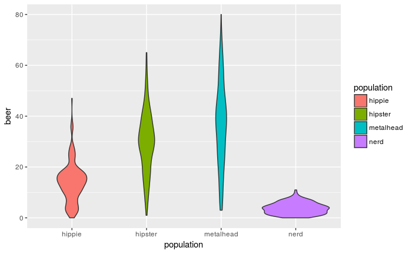

```r
ggplot(stereotypes, aes(population, beer, fill = population)) + geom_violin()
```

**Activity Break:**  
*1. Make a graph that visually describes the difference between beer consumption between gender in the nerd category*

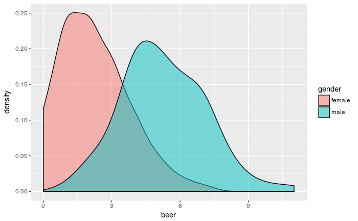

```r
nerd <- subset(stereotypes, population == "nerd")
ggplot(nerd, aes(beer, fill = gender)) + geom_density(alpha = I(0.5))
```

*2. Using the ggplot2 documentation, explore three different geoms, using either the full data or a subset of the data. Tell me something interesting about the data.*

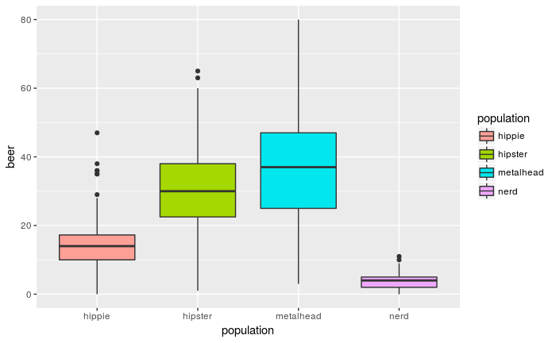

```r
#This will generate a boxplot for each of the 4 subtypes of the population and their beer consumption
ggplot(data = stereotypes, aes(x = population, y = beer, fill = population)) + geom_boxplot() + scale_fill_hue(l = 80)
```

This graph tells us that metalheads average beer consumption is the highest in comparison to the other population groups.

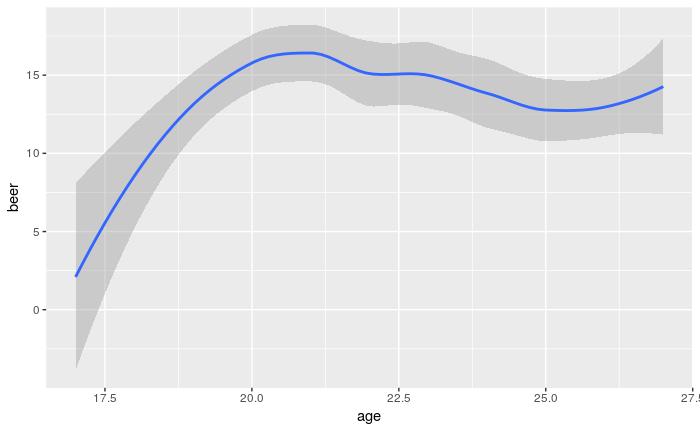

```r
hippie <- subset(stereotypes, population == "hippie")
ggplot(data = hippie, aes(x = age, y = beer)) + geom_smooth(method = 'loess')
```

This graphs gives us a line representation that illustrates the relationship between age with drinking beer in the hippie population. The age range from 20 - 21 is associated with highest number of average beer consmption.

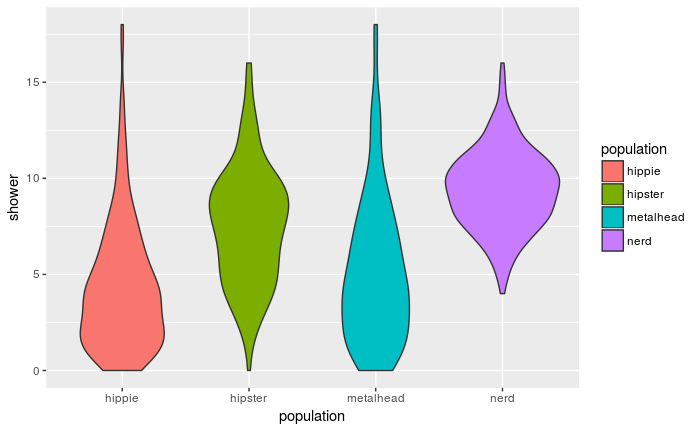

```r
ggplot(stereotypes, aes(x = population, y = shower)) + geom_violin(aes(fill = population))
```

This graph gives us a violin graph illustrating the showering habits among the 4 different populations. The results suggest that the nerd population showers the most frequently on average among the 4 different types.

*3. From yor exploration of the stereotypes data, make three hypothesis about the data*

- The nerd population showers the most
- The metalhead population drinks the most
- The hippie population showers the least

**Activity Break:**  
*1. With the p base layer, make a unique plot by adding additional layers.*

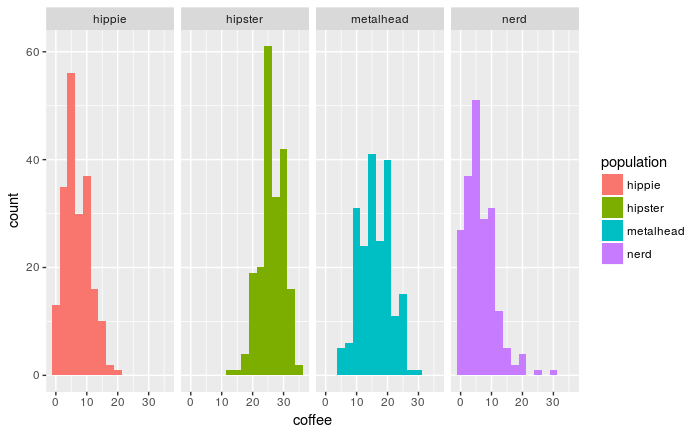

```r
p <- ggplot(data = stereotypes, aes(coffee))
p + geom_histogram(aes(fill = population), binwidth = 2.5) + facet_grid(~population)
```

using `fill =` allows us to fill the color of the graph.  
using `color =` allows us to change the border color of the graph. scal_color_hue() can additionally be used to change the color.

**Activity Break:**

*1. Read about and use the following modifers correctly with any portion of the sterotypes dataset you want*  
*2. Modify color with scale_color_hue()*  
*3. Make a tricket out boxplot using the stereotypes data. Use at least 3 of the asethetics option available for geom_boxplot.*

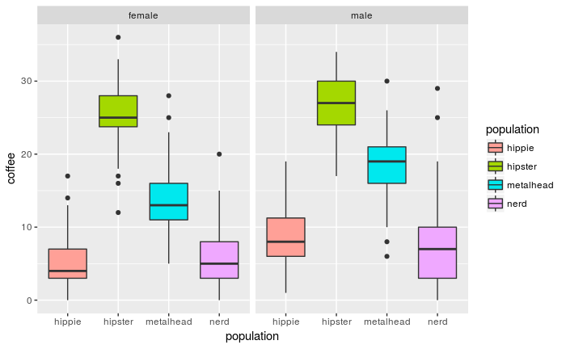

```r
p <- ggplot(data = stereotypes, aes(x = population, y = coffee))
p + geom_boxplot(aes(fill = population)) + scale_fill_hue(l = 80) + facet_grid(~gender)
```

## Exercise 12

*Use ggplot to explore the relationship between score (“Score”) and alignment length(“len”). Provide a plot that illustrates the relationship and describe the relationship in words.*

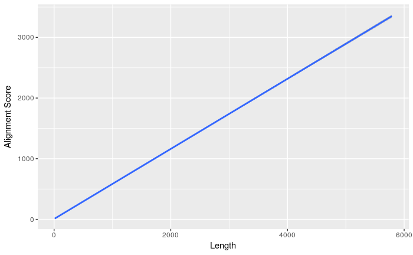

```r
q <- ggplot(data = fly.worm, aes(x = fly.worm["len"], y = fly.worm["Score"]))
q + geom_smooth(method = 'gam') + scale_x_continuous() + scale_y_continuous() + xlab("Length") +ylab("Alignment Score")
```

As the sequence length increases, the overall trend shows that the score also increases in a linear fashion. This makes sense as increased sequence length correlates with more amino acids being compared to one another.

## Excercise 13

*While you might expect that BLAST results with long alignments would have high scores, this is not always the case. Form a hypothesis as to what might influence the relationship between alignment length and score. Use ggplot to make a new plot to explore this hypothesis. Does the plot support your hypothesis or not? State your hypothesis, provide the code for your plot, and state your conclusion.*

Long alignments will not always gaurantee a high score. If conserved sequences are compared it will give a high score, however, the longer the sequence the higher chance of having mismatches. Mismatches can thus lower the alignment score.

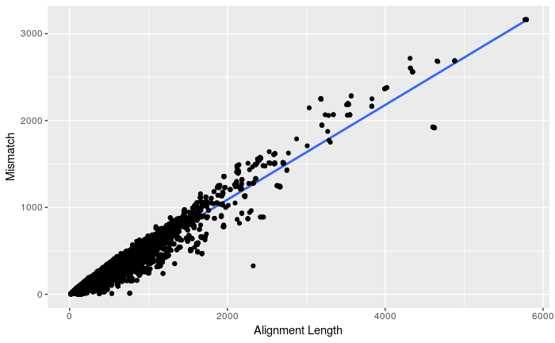

```r
#Create a plot observing the relationship between alignment length and number of mismatches
lahs <- ggplot(data = fly.worm, aes(x = fly.worm["len"], y = fly.worm["mis"]))
lahs + geom_smooth(method = 'gam') + geom_point() + xlab("Alignment Length") + ylab("Mismatch") + scale_x_continuous() + scale_y_continuous()
```

From the graph we are able to observe a linear relationship between alignment length and number of mismatches, thus supporting my hypothesis.

**Turning in the assignment**

- Click the “Preview” Button to generate an up-to-date html version of your notebook. Check it to make sure you are happy with its content.
- add your .Rmd and .nb.html files to the repository and commit the changes.
- push the changes